# Lab: Mapping Locations

Xuemao Zhang

June 26, 2019

## Introduction

- In this session, we use one example to show how to map locations.
- Install the following packages if you don’t have them.

```
                install.packages("devtools");
                devtools::install_github("wmurphyrd/fiftystater");
                install.packages("dplyr");
                install.packages("stringr");
                install.packages('maps');
                install.packages('ggmap');
                install.packages('ggplot2');
                install.packages('magick');
```

- Consider the unemployment rates data for the 50 largest cities in US from 2013 to 2017. The data are available from [Bureau of Labor Statistics](https://www.bls.gov/lau/).

## Unemployment Rates City Data

### Some data manipulations

- The data are in the form of HTML tables on https://www.bls.gov/lau/:

  ```
  - https://www.bls.gov/lau/lacilg13.htm
  - https://www.bls.gov/lau/lacilg14.htm
  - https://www.bls.gov/lau/lacilg15.htm
  - https://www.bls.gov/lau/lacilg16.htm
  - https://www.bls.gov/lau/lacilg17.htm
  ```

- The data were downloaded and combined in the file `UnemploymentCity.csv`.

```r
City0 = read.csv("F:/DataCamp/data/UnemploymentCity.csv",header=TRUE, sep=",");
dim(City0);
```

```
## [1] 250   3
```

```r
str(City0);
```

```
## 'data.frame':    250 obs. of  3 variables:
##  $ city: Factor w/ 50 levels "Albuquerque city, NM",..: 35 17 34 3 30 45 47 48 43 39 ...
##  $ rate: num  4.1 4.4 4.5 4.6 4.6 4.6 5 5.4 5.5 5.7 ...
##  $ year: int  2013 2013 2013 2013 2013 2013 2013 2013 2013 2013 ...
```

```r
City0$city=as.character(City0$city);
str(City0);
```

```
## 'data.frame':    250 obs. of  3 variables:
##  $ city: chr  "Omaha city, NE" "Honolulu County/city, HI" "Oklahoma City city, OK" "Austin city, TX" ...
##  $ rate: num  4.1 4.4 4.5 4.6 4.6 4.6 5 5.4 5.5 5.7 ...
##  $ year: int  2013 2013 2013 2013 2013 2013 2013 2013 2013 2013 ...
```

```r
unique(City0$city);
```

```
##  [1] "Omaha city, NE"
##  [2] "Honolulu County/city, HI"
##  [3] "Oklahoma City city, OK"
##  [4] "Austin city, TX"
##  [5] "Minneapolis city, MN"
##  [6] "Seattle city, WA"
##  [7] "Tulsa city, OK"
##  [8] "Virginia Beach city, VA"
##  [9] "San Francisco County/city, CA"
## [10] "Raleigh city, NC"
## [11] "San Antonio city, TX"
## [12] "Houston city, TX"
## [13] "Nashville-Davidson (consolidated) city, TN"
## [14] "Fort Worth city, TX"
## [15] "Boston city, MA"
```

[output cut: 35 more lines]

- To plot the cities on the map, we need to knowhe the coordinates. The `us.cities` database can be used.

```r
library(maps);
data(us.cities);
str(us.cities);
```

```
## 'data.frame':    1005 obs. of  6 variables:
##  $ name       : chr  "Abilene TX" "Akron OH" "Alameda CA" "Albany GA" ...
##  $ country.etc: chr  "TX" "OH" "CA" "GA" ...
##  $ pop        : int  113888 206634 70069 75510 93576 45535 494962 44933 127159 88857 ...
##  $ lat        : num  32.5 41.1 37.8 31.6 42.7 ...
##  $ long       : num  -99.7 -81.5 -122.3 -84.2 -73.8 ...
##  $ capital    : int  0 0 0 0 2 0 0 0 0 0 ...
```

- First, add a variable “state”.

```r
library(stringr); library(dplyr);
City0=mutate(City0, state=stringr::str_sub(city, -2, -1));  #extract the state name: the last two characters from the city name
head(City0);
```

```
##                       city rate year state
## 1           Omaha city, NE  4.1 2013    NE
## 2 Honolulu County/city, HI  4.4 2013    HI
## 3   Oklahoma City city, OK  4.5 2013    OK
## 4          Austin city, TX  4.6 2013    TX
## 5     Minneapolis city, MN  4.6 2013    MN
## 6         Seattle city, WA  4.6 2013    WA
```

- We need to manipulate the data `City` a little bit. To use the lat and long information, we ddd the “name” variable in ‘us.cities’ in the form of city name + state abbreviatioin separated by a space.
- Some ‘city’ values contain “(consolidated) city,”, “County/city,” or “city,”.

```r
library(dplyr);
City1=mutate(City0, name0=gsub(pattern="(consolidated) city, ", replacement='', city,fixed=TRUE));
City2=mutate(City1, name1=gsub(pattern="County/city, ", replacement='', name0,fixed=TRUE));
City=mutate(City2, name=gsub(pattern="city, ", replacement='', name1,fixed=TRUE));
unique(City$name);
```

```
##  [1] "Omaha NE"                       "Honolulu HI"
##  [3] "Oklahoma City OK"               "Austin TX"
##  [5] "Minneapolis MN"                 "Seattle WA"
##  [7] "Tulsa OK"                       "Virginia Beach VA"
##  [9] "San Francisco CA"               "Raleigh NC"
## [11] "San Antonio TX"                 "Houston TX"
## [13] "Nashville-Davidson TN"          "Fort Worth TX"
## [15] "Boston MA"                      "Albuquerque NM"
## [17] "Dallas TX"                      "Wichita KS"
## [19] "Columbus OH"                    "Portland OR"
## [21] "Charlotte NC"                   "Denver CO"
## [23] "Mesa AZ"                        "Phoenix AZ"
## [25] "San Jose CA"                    "Tucson AZ"
## [27] "El Paso TX"                     "Jacksonville FL"
## [29] "Kansas City MO"                 "Miami FL"
## [31] "Louisville-Jefferson County KY" "San Diego CA"
## [33] "Colorado Springs CO"            "Indianapolis IN"
## [35] "Washington DC"                  "Cleveland OH"
## [37] "New York NY"                    "Atlanta GA"
## [39] "Oakland CA"                     "Sacramento CA"
## [41] "Baltimore MD"                   "Memphis TN"
## [43] "Chicago IL"                     "Las Vegas NV"
## [45] "Milwaukee WI"                   "Los Angeles CA"
## [47] "Philadelphia PA"                "Long Beach CA"
## [49] "Fresno CA"                      "Detroit MI"
```

### Get city lat and long information

- Combine the two data frames City and us.cities to get lat and long information.

```r
CityRate=dplyr::left_join(City, us.cities, by="name");
which(complete.cases(CityRate)==F);  ##Three city names do not match
```

```
##  [1]  13  31  35  66  76  91 117 123 142 159 170 194 202 229 246
```

```r
CityRate$name[13]; CityRate$name[31];  CityRate$name[35];
```

```
## [1] "Nashville-Davidson TN"
```

```
## [1] "Louisville-Jefferson County KY"
```

```
## [1] "Washington DC"
```

- Change the names of these three cities to match us.cities$name.

```r
City$name=ifelse(City$name=="Nashville-Davidson TN", "Nashville TN", ifelse(City$name=="Louisville-Jefferson County KY", "Louisville KY", ifelse(City$name=="Washington DC","WASHINGTON DC", City$name)));
```

- Try to combine the two data frames City and us.cities again.

```r
CityRate=dplyr::left_join(City, us.cities, by="name");
which(complete.cases(CityRate)==F);
```

```
## integer(0)
```

```r
head(CityRate);
```

```
##                       city rate year state                    name0
## 1           Omaha city, NE  4.1 2013    NE           Omaha city, NE
## 2 Honolulu County/city, HI  4.4 2013    HI Honolulu County/city, HI
## 3   Oklahoma City city, OK  4.5 2013    OK   Oklahoma City city, OK
## 4          Austin city, TX  4.6 2013    TX          Austin city, TX
## 5     Minneapolis city, MN  4.6 2013    MN     Minneapolis city, MN
## 6         Seattle city, WA  4.6 2013    WA         Seattle city, WA
##                    name1             name country.etc    pop   lat    long
## 1         Omaha city, NE         Omaha NE          NE 417809 41.26  -96.01
## 2            Honolulu HI      Honolulu HI          HI 386345 21.32 -157.80
## 3 Oklahoma City city, OK Oklahoma City OK          OK 538141 35.47  -97.51
## 4        Austin city, TX        Austin TX          TX 683404 30.31  -97.75
## 5   Minneapolis city, MN   Minneapolis MN          MN 364726 44.96  -93.27
## 6       Seattle city, WA       Seattle WA          WA 570430 47.62 -122.35
##   capital
## 1       0
## 2       2
## 3       2
## 4       2
## 5       0
## 6       0
```

### Get city lat and long information using `ggmap`

- An easier way to get lat and long information of a location is to use the package ggmap.
- As of mid-2018, the Google Maps Platform requires a registered API key.
- In R, ggmap functions that use Google’s services no longer function out of the box, since the user has to setup an account with Google, enable the relevant APIs, and then tell R about the user’s setup.
- To obtain an API key and enable services, go to https://cloud.google.com/maps-platform/.

```
library(ggmap);
geo=geocode(location = City0$city, output="latlon", source="dsk");
# datasciencetoolkit.org terminated its map service, sorry!
str(geo);
head(geo);
which(complete.cases(geo)==F);
#combine the two data frames
CityRate0 = dplyr::bind_cols(City0, geo);
str(CityRate0);
```

## Map Locations

- We map the 50 cities using the `fiftystater` package.
- fiftystater is a simple data package to ease the process of creating choropleths in ‘ggplot2’ with all fifty U.S. states and Washington D.C., including Alaska and Hawaii as insets.
- For example, we just map these fifty cities. But we have to change the long and lat information for the city in HI (Hawaii) manually.

```r
CityRate$long = ifelse(CityRate$state=="HI", CityRate$long+53.60,CityRate$long);
CityRate$lat = ifelse(CityRate$state=="HI", CityRate$lat+2.91,CityRate$lat);
```

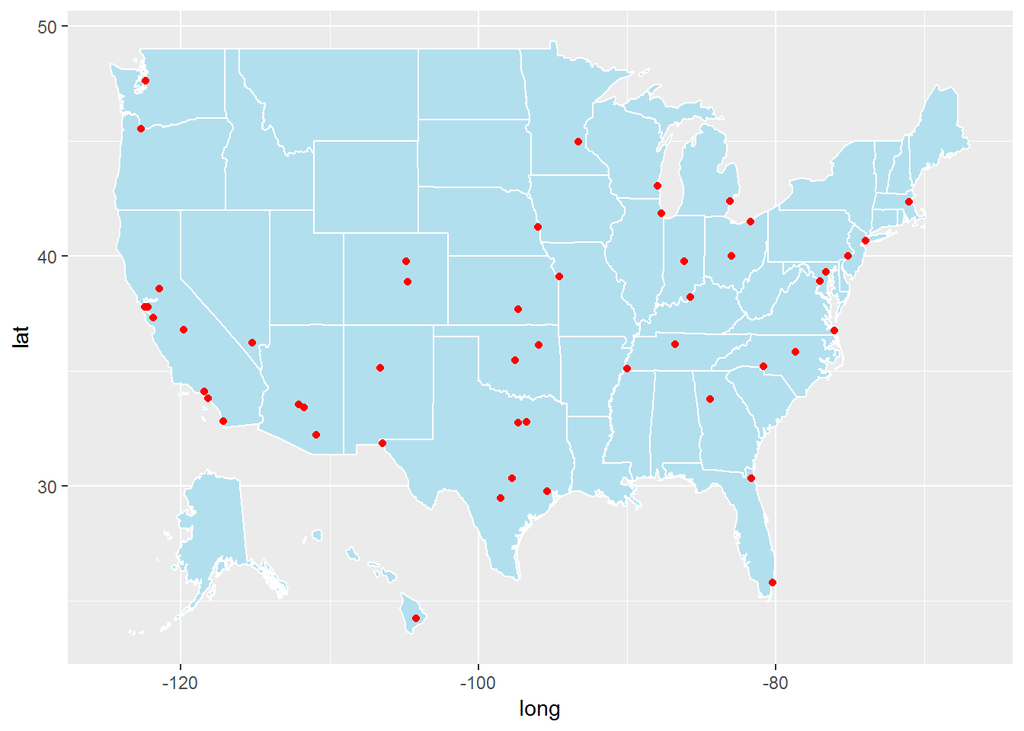

```r
library(ggplot2);
library(fiftystater);
CityRate2013=filter(CityRate, year==2013);
data("fifty_states");
ggplot() + geom_polygon(data=fifty_states, aes(x=long, y=lat, group = group),color="white", fill="lightblue2")+
geom_point(data = CityRate2013,aes(x=long, y=lat),col='red');
```

- We also can plot the cities with size proportional to their umemployment rates.

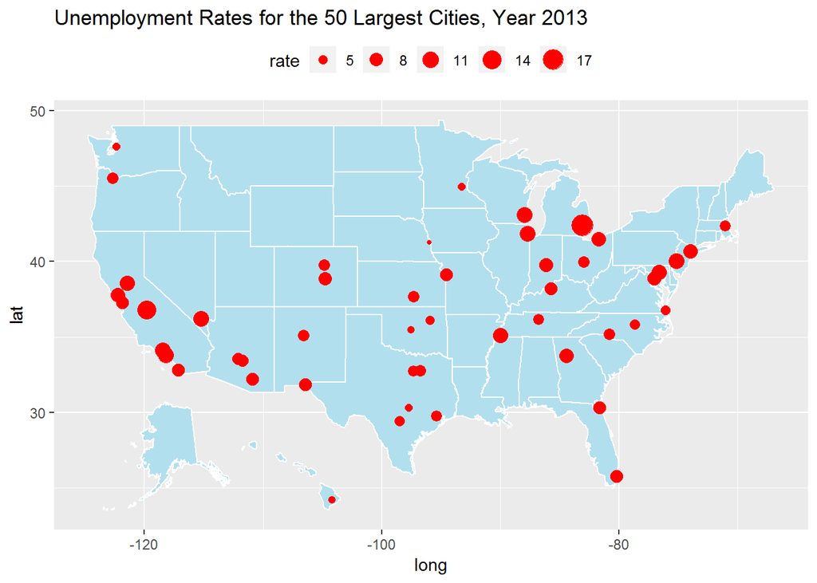

```r
ggplot() + geom_polygon(data=fifty_states, aes(x=long, y=lat, group = group),color="white", fill="lightblue2")+
geom_point(data = CityRate2013,aes(x=long, y=lat,size=rate),col='red')+
  scale_size(range=c(1,6), breaks=seq(2, 20, 3))+
  ggtitle("Unemployment Rates for the 50 Largest Cities, Year 2013")+
  theme(legend.position="top");
```

## Animated Map

- We first define a function of year.

```r
PlotRate= function(x)
{
data_year=dplyr::filter(CityRate, year==x);
#subset data in the year x
ggplot() +
geom_polygon(data=fifty_states, aes(x=long, y=lat, group = group),color="white", fill="lightblue2")+
geom_point(data = data_year,aes(x=long, y=lat,size=rate),col='red')+
  scale_size(range=c(1,6), breaks=seq(2, 20, 3))+
  ggtitle(paste("Unemployment Rates for the 50 Largest Cities, Year",x))+
  theme(legend.position="bottom");
}
```

- Animated map

```r
library(magick);
```

```r
img=image_graph(width=600,height=400,res=96);
for( i in 2013:2017) print(PlotRate(i));
dev.off();
```

```
## # A tibble: 5 x 7
##   format width height colorspace matte filesize density
##   <chr>  <int>  <int> <chr>      <lgl>    <int> <chr>
## 1 gif      600    400 sRGB       TRUE         0 72x72
## 2 gif      600    400 sRGB       TRUE         0 72x72
## 3 gif      600    400 sRGB       TRUE         0 72x72
## 4 gif      600    400 sRGB       TRUE         0 72x72
## 5 gif      600    400 sRGB       TRUE         0 72x72
```

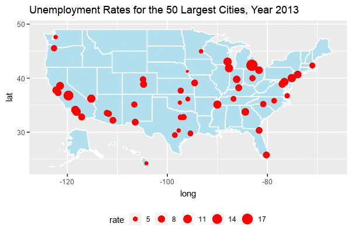

```r
RateAnimation = image_animate(img, fps = 1);
print(RateAnimation);
```